# Big Data File Formats

## Introduction

We define Big Data broadly as "data so big it becomes difficult to manage".

This difficulty can be related to the "Three Vs":

- Volume
- Velocity
- Variety

With a case study, we will show how we managed Big Data Volume in R.

## Case Study: Meteorological Data

We are using climate data from the [MACA downscaling](https://climate.northwestknowledge.net/MACA/) datasets.

## File Formats

We compared the following file formats and their performance:

- [NetCDF](https://earthdata.nasa.gov/user-resources/standards-and-references/netcdf-4hdf5-file-format)
- [RData](https://stat.ethz.ch/R-manual/R-devel/library/base/html/load.html)
- [CSV](https://en.wikipedia.org/wiki/Comma-separated_values)
- SQLite
- [MonetDBLite](https://en.wikipedia.org/wiki/MonetDB)
- [XDF](https://docs.microsoft.com/en-us/machine-learning-server/r/concept-what-is-xdf)

## Packages

We will use these R packages:

- [ncdf4](https://cran.r-project.org/web/packages/ncdf4/index.html)
- [raster](https://cran.r-project.org/web/packages/raster/index.html)
- [data.table](https://cran.r-project.org/web/packages/data.table/index.html)
- [dplyr](https://cran.r-project.org/web/packages/dplyr/index.html)
- [dbplyr](https://cran.r-project.org/web/packages/dbplyr/index.html)
- [RevoScaleR](https://docs.microsoft.com/en-us/machine-learning-server/r-reference/revoscaler/revoscaler)
- [DBI](https://cran.r-project.org/web/packages/DBI/index.html)
- [RSQLite](https://cran.r-project.org/web/packages/RSQLite/index.html)
- [MonetDBLite](https://cran.r-project.org/web/packages/MonetDBLite/index.html)
- [pryr](https://cran.r-project.org/web/packages/pryr/index.html)

## Common Approaches to Big Data

We used most of these tools and techniques in our case study.

- Sampling
- Bigger hardware
- Storage (e.g., files or databases) and "chunking"
- Optimized software compilation to support hardware features
- Alternative libraries (packages)
- Alternative interpreters
- Alternative languages

(Modified from [Five ways to handle Big Data in R](https://www.r-bloggers.com/five-ways-to-handle-big-data-in-r/) by Oliver Bracht.)

## Requirements Analysis

To select the best tools for the job, we considered:

- Security/Access Requirements
- Software Requirements
- Storage Requirements
- Memory Requirements
- Processing Requirements
- Performance Requirements

## File Size

The SQL-based formats were about the size as RData, with XDF, NetCDF, and GZipped CSV much smaller and uncompressed CSV much larger.

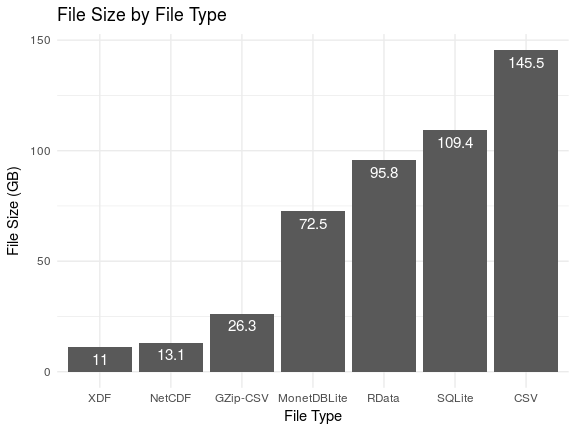

## Benchmark Query: SQL

Our benchmark query is a simple filter/group/summarize operation expressed in SQL as:

```
SELECT scenario,
       MAX(tasmax) AS maxtmax,
       MIN(tasmin) AS mintmin
FROM metdata
WHERE NOT tasmax = 0 AND NOT tasmin = 0
GROUP BY scenario;
```

Where `maxtmax` is the maximum of the daily maximum temperatures and `mintmin` is the minimum of the daily minimum temperatures.

## Benchmark Query: *dplyr* and *data.table*

This is equivalent to this *dplyr* pipeline:

```
df %>% filter(tasmax != 0, tasmin != 0) %>%
       group_by(scenario) %>%
       summarise(maxtmax=max(tasmax, na.rm = TRUE),
                 mintmin=min(tasmin, na.rm = TRUE))
```

Or this *data.table* operation:

```
dt[tasmax != 0 & tasmin != 0,
   .(maxtmax=max(tasmax, na.rm = TRUE),
     mintmin=min(tasmin, na.rm = TRUE)),
   by = list(scenario)]
```

## Benchmark Query: *rxSummary*

With XDF, we can use the *rxSummary* function:

```
rxSummary(~tasmax:scenario + tasmin:scenario,
          data=xdf.dso, removeZeroCounts = TRUE,
          summaryStats=c("Max", "Min"))
```

But to get the output formatted as in the previous examples, we use *dplyr* to reformat it:

```
df.rxs$categorical[[1]][c('scenario', 'Max')] %>%
    full_join(df.rxs$categorical[[2]][c("scenario", 'Min')],
              by = 'scenario') %>%
    rename(maxtmax=Max, mintmin=Min) %>% mutate(model=mod)
```

Where `df.rxs` is the `data.frame` object we used to store the output of *rxSummary*.

## On-Disk Queries

MonetDBLite was much faster than SQL. XDF was fast too, but it's query features are more limited compared to the expressiveness of SQL.

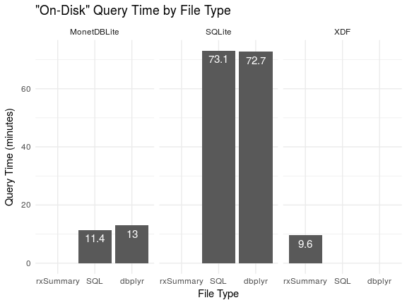

## File Import Times

MonetDBLite was the fastes to import bay far. SQLite, NetCDF, and GZipped CSV took much to long to read to be considered competitive with the others.

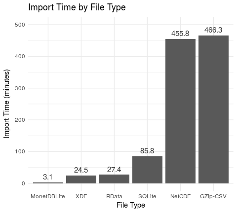

## "In-Memory" Calculation Time

*data.table* is faster than *dplyr*. Making sure factors are coded as factors instead of characters can really help, especially when using *dplyr*. Specify column types as you import, as it will take a long time to convert after import.

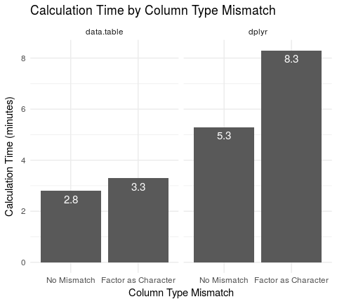

## Max and Min Temperatures

It takes about 3 hours and 12 minutes to summarize all of the data with `rxSummary`:

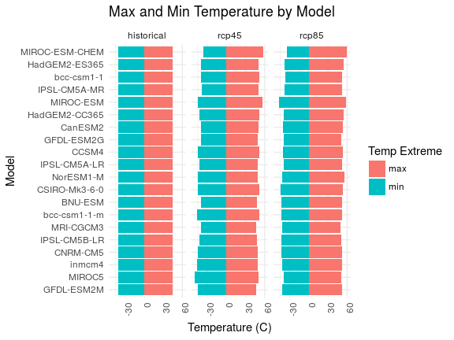

## Summary

By gathering project requirements first, then evaluating various options that fit those requirements, we were able to find two primary data file types to use: MonetDBLite and XDF.

Both will perform similarly in terms of speed, with XDF taking less storage space but more time to read into memory. If the operations to be performed will consume too much memory, then MonetDBLite will also allow some of the calculations to be performed in SQL before loading the entire dataset into memory. Or, either file type can be subsetted during import to implement a "chunking" approach. So, if minimizing storage consumption is a priority, then we may prefer XDF, but if execution time and memory conservation are priorities, then we may prefer MonetDBLite.

It is quicker to import our data into a `data.frame` rather than converting to a `data.table` during or after import. But using the *data.table* bracket-notation for some operations will be faster than performing those same operations with *dplyr* functions. So, if we have lots of operations to perform in memory, it may be worth the overhead of converting data frame's to data tables in order to use the *data.table* package.